# **Project 1 - Charlotte's Neighborhood Crime Over Time**

## Introduction

Crime is a concern for many urban areas in the United States, and Charlotte is no exception. It is important to understand crime patterns and statistics to help communities and law enforcement agencies develop plans, allocate resources, and engage with the community to improve public safety. The Charlotte-Mecklenburg Police Department (CMPD) regularly publishes detailed crime reports. As of July 22, 2024, overall crime in Charlotte has seen a slight increase of 1% compared to the previous year. This includes various types of crimes, categorized broadly into violent crimes and property crimes.

https://data.charlottenc.gov/datasets/charlotte::cmpd-incidents-1/about

## Dataset

The dataset is available from the city of Charlotte's open data portal. Data is available in various formats including CSV and contains all CMPD incident reports from 2017 through 2024. It contains 688,973 observations and 29 features.

These features are 'X', 'Y', 'YEAR', 'INCIDENT_REPORT_ID', 'LOCATION', 'CITY', 'STATE', 'ZIP', 'X_COORD_PUBLIC', 'Y_COORD_PUBLIC', 'LATITUDE_PUBLIC', 'LONGITUDE_PUBLIC', 'DIVISION_ID', 'CMPD_PATROL_DIVISION', 'NPA', 'DATE_REPORTED', 'DATE_INCIDENT_BEGAN', 'DATE_INCIDENT_END', 'ADDRESS_DESCRIPTION', 'LOCATION_TYPE_DESCRIPTION', 'PLACE_TYPE_DESCRIPTION', 'PLACE_DETAIL_DESCRIPTION', 'CLEARANCE_STATUS', 'CLEARANCE_DETAIL_STATUS', 'CLEARANCE_DATE', 'HIGHEST_NIBRS_CODE', 'HIGHEST_NIBRS_DESCRIPTION', 'OBJECTID', and 'GlobalID'.

I used CMPD_PATROL_DIVISION and the PLACE_DETAIL-DESCRIPTION columns for this project. The CMPD_PATROL_DIVISION column provides the names of the patrol division for a particular area of the city such as "North" and "Steele Creek" divisions. These divisions will represent the neighborhoods. The PLACE_DETAIL-DESCRIPTION provides the location where a crime took place. For example, "Private Resident", "Open Field", and "Air/Bus/Train Terminal". These columns will allow us to compare neighborhoods and look within neighborhood to see if certain locations have experienced above average crime incidents.

## Pre-Processing

Pre-processing is one of the most important steps. By thoroughly cleaning the data, we will improve the accuracy of our model and save time by removing errors in advance.

The pre-processing begins with importing the csv dataset. Initially, I received a “ParserError: Error tokenizing data. C error” which is caused when python process senses some rows have more data than expected. I added `on_bad_lines ='skip'` to the import which would skip any bad rows of data. After the import, there were no rows removed. Its shape is (688973, 29).

After `CLT_crime.head(3)`, I noticed both 'X'and 'X_COORD_PUBLIC' contained the same value. The only differece was 'X' was unrounded and 'X_COORD_PUBLIC' was rounded. This was the same situation for 'Y' and 'Y_COORD_PUBLIC'. So, 'X' and 'Y' were removed. Metadata could not be located on the website to determine the purpose of 'X_COORD_PUBLIC' and 'Y_COORD_PUBLIC', so the decision was made to retain the information.

In addition, INCIDENT_REPORT_ID, OBJECTID, and GlobalID were removed from the dataset. The INCIDENT_REPORT_ID represents the unique ID associated with each incident. Metadata could not be discovered for GlobalID. So, to save space and streamline the number of columns, I decided to remove the column. OBJECTID is similar to the index for the dataset. I decided after pre-processing the dataset, I would add my own index to the beginning of the dataframe.

```python
# @title
# Setup our workspace

# Render our plots inline
%matplotlib inline

import pandas as pd
import matplotlib.pyplot as plt
import numpy as np

plt.style.use('ggplot')
plt.rcParams['figure.figsize'] = (13, 7)
```

```python
# import data set
data_file = '/content/sample_data/CMPD_Incidents.csv';

CLT_crime = pd.read_csv(data_file, on_bad_lines = 'skip')
pd.set_option('display.max_columns', None)
```

```python
CLT_crime.shape
```

```
(688973, 29)
```

```python
CLT_crime.head(4)
```

|  | X | Y | YEAR | INCIDENT_REPORT_ID | LOCATION | CITY | STATE | ZIP | X_COORD_PUBLIC | Y_COORD_PUBLIC | LATITUDE_PUBLIC | LONGITUDE_PUBLIC | DIVISION_ID | CMPD_PATROL_DIVISION | NPA | DATE_REPORTED | DATE_INCIDENT_BEGAN | DATE_INCIDENT_END | ADDRESS_DESCRIPTION | LOCATION_TYPE_DESCRIPTION | PLACE_TYPE_DESCRIPTION | PLACE_DETAIL_DESCRIPTION | CLEARANCE_STATUS | CLEARANCE_DETAIL_STATUS | CLEARANCE_DATE | HIGHEST_NIBRS_CODE | HIGHEST_NIBRS_DESCRIPTION | OBJECTID | GlobalID |
| --- | --- | --- | --- | --- | --- | --- | --- | --- | --- | --- | --- | --- | --- | --- | --- | --- | --- | --- | --- | --- | --- | --- | --- | --- | --- | --- | --- | --- | --- |
| 0 | 1.405570e+06 | 573263.999990 | 2017 | 20170713-1513-05 | 10500 TURKEY POINT DR | CHARLOTTE | NC | 28214 | 1405570 | 573264 | 35.308755 | -80.992632 | 11 | North | 156 | 2017/07/13 00:00:00+00 | 2016/09/16 00:00:00+00 | 2017/07/13 00:00:00+00 | Location of occurrence | Other | Residential | Private Residence | Open | Open | NaN | 13C | Intimidation | 1 | {EFBEB3D4-024E-4E5A-B0D2-E449A913F081} |
| 1 | 1.454066e+06 | 544138.999841 | 2022 | 20220503-0227-00 | 1000 N CALDWELL ST | CHARLOTTE | NC | 28205 | 1454066 | 544139 | 35.231309 | -80.828305 | 06 | Eastway | 22 | 2022/05/03 00:00:00+00 | 2022/05/03 00:00:00+00 | NaN | Location of occurrence | Outdoors | Open Area | Open Field | Cleared by Arrest | Cleared by Arrest | 2022/05/03 00:00:00+00 | 35A | Drug/Narcotic Violations | 2 | {8DD3EEF4-7FAA-40A1-BDA4-E7C4B276BF03} |
| 2 | 1.476909e+06 | 568895.999868 | 2019 | 20190822-2020-01 | 100 E MCCULLOUGH DR | CHARLOTTE | NC | 28262 | 1476909 | 568896 | 35.300454 | -80.753286 | 14 | University City | 219 | 2019/08/22 00:00:00+00 | 2019/08/22 00:00:00+00 | 2019/08/22 00:00:00+00 | Location of occurrence | Parking Lot | Commercial Place | Hotel/Motel | Cleared by Arrest | Cleared by Arrest | 2019/08/22 00:00:00+00 | 280 | Stolen Property Offenses | 3 | {163A308E-1CB0-4CFB-9406-D656232B7114} |
| 3 | 1.449971e+06 | 543008.000135 | 2023 | 20230508-0709-02 | 100 W 5TH ST | CHARLOTTE | NC | 28202 | 1449971 | 543008 | 35.227994 | -80.841946 | 01 | Central | 476 | 2023/05/08 00:00:00+00 | 2023/05/06 00:00:00+00 | 2023/05/06 00:00:00+00 | Location of occurrence | Indoors | Commercial Place | Bar/Tavern/Nightclub | Open | Open | NaN | 23H | All Other Thefts | 4 | {5D88C5F8-CBEF-44C6-8F40-D24C0B212E29} |

Next, I checked for missing values by using `CLT_crime.info()`. We can see six columns were missing values: STATE, ZIP, CMPD_PATROL-DIVISION, DATE_INCIDENT_END, ADDRESS_DESCRIPTION, and CLEARANCE DATE. The decision was made not to drop any rows from the dataset.

ZIP and ADDRESS_DESCRIPTION which would have the smallest impact to the project. I will not be using those columns in my analysis.

Lastly, the data set was indexed using `CLT_crime.index = [x for x in range(1, len(CLT_crime.values)+1)]` Normally, when data is imported python automatically creates an index; however, the first row is index as 0 rather than 1. Refer to the inital dataset displayed above and note the 0 next to the first row. The index is named ID.

```python
CLT_crime.isna().sum()
```

|  | 0 |
| --- | --- |
| X | 0 |
| Y | 0 |
| YEAR | 0 |
| INCIDENT_REPORT_ID | 0 |
| LOCATION | 0 |
| CITY | 0 |
| STATE | 5 |
| ZIP | 222686 |
| X_COORD_PUBLIC | 0 |
| Y_COORD_PUBLIC | 0 |
| LATITUDE_PUBLIC | 0 |
| LONGITUDE_PUBLIC | 0 |
| DIVISION_ID | 0 |
| CMPD_PATROL_DIVISION | 627 |
| NPA | 0 |
| DATE_REPORTED | 0 |
| DATE_INCIDENT_BEGAN | 0 |
| DATE_INCIDENT_END | 168694 |
| ADDRESS_DESCRIPTION | 3 |
| LOCATION_TYPE_DESCRIPTION | 0 |
| PLACE_TYPE_DESCRIPTION | 0 |
| PLACE_DETAIL_DESCRIPTION | 0 |
| CLEARANCE_STATUS | 0 |
| CLEARANCE_DETAIL_STATUS | 0 |
| CLEARANCE_DATE | 411157 |
| HIGHEST_NIBRS_CODE | 0 |
| HIGHEST_NIBRS_DESCRIPTION | 0 |
| OBJECTID | 0 |
| GlobalID | 0 |

**dtype:** int64

```python
CLT_crime.info()
```

```
<class 'pandas.core.frame.DataFrame'>
RangeIndex: 688973 entries, 0 to 688972
Data columns (total 29 columns):
 #   Column                     Non-Null Count   Dtype
---  ------                     --------------   -----
 0   X                          688973 non-null  float64
 1   Y                          688973 non-null  float64
 2   YEAR                       688973 non-null  int64
 3   INCIDENT_REPORT_ID         688973 non-null  object
 4   LOCATION                   688973 non-null  object
 5   CITY                       688973 non-null  object
 6   STATE                      688968 non-null  object
 7   ZIP                        466287 non-null  object
 8   X_COORD_PUBLIC             688973 non-null  int64
 9   Y_COORD_PUBLIC             688973 non-null  int64
```

[output cut: 21 more lines]

```python
# @title
CLT_crime = CLT_crime.drop(['X','Y','INCIDENT_REPORT_ID', 'OBJECTID','GlobalID', 'ZIP'], axis=1)
```

```python
# @title
CLT_crime.index = [x for x in range(1, len(CLT_crime.values)+1)]

# add index field name
CLT_crime.index.name = 'id'
CLT_crime.head(3)
```

| id | YEAR | LOCATION | CITY | STATE | X_COORD_PUBLIC | Y_COORD_PUBLIC | LATITUDE_PUBLIC | LONGITUDE_PUBLIC | DIVISION_ID | CMPD_PATROL_DIVISION | NPA | DATE_REPORTED | DATE_INCIDENT_BEGAN | DATE_INCIDENT_END | ADDRESS_DESCRIPTION | LOCATION_TYPE_DESCRIPTION | PLACE_TYPE_DESCRIPTION | PLACE_DETAIL_DESCRIPTION | CLEARANCE_STATUS | CLEARANCE_DETAIL_STATUS | CLEARANCE_DATE | HIGHEST_NIBRS_CODE | HIGHEST_NIBRS_DESCRIPTION |
| --- | --- | --- | --- | --- | --- | --- | --- | --- | --- | --- | --- | --- | --- | --- | --- | --- | --- | --- | --- | --- | --- | --- | --- |
| 1 | 2017 | 10500 TURKEY POINT DR | CHARLOTTE | NC | 1405570 | 573264 | 35.308755 | -80.992632 | 11 | North | 156 | 2017/07/13 00:00:00+00 | 2016/09/16 00:00:00+00 | 2017/07/13 00:00:00+00 | Location of occurrence | Other | Residential | Private Residence | Open | Open | NaN | 13C | Intimidation |
| 2 | 2022 | 1000 N CALDWELL ST | CHARLOTTE | NC | 1454066 | 544139 | 35.231309 | -80.828305 | 06 | Eastway | 22 | 2022/05/03 00:00:00+00 | 2022/05/03 00:00:00+00 | NaN | Location of occurrence | Outdoors | Open Area | Open Field | Cleared by Arrest | Cleared by Arrest | 2022/05/03 00:00:00+00 | 35A | Drug/Narcotic Violations |
| 3 | 2019 | 100 E MCCULLOUGH DR | CHARLOTTE | NC | 1476909 | 568896 | 35.300454 | -80.753286 | 14 | University City | 219 | 2019/08/22 00:00:00+00 | 2019/08/22 00:00:00+00 | 2019/08/22 00:00:00+00 | Location of occurrence | Parking Lot | Commercial Place | Hotel/Motel | Cleared by Arrest | Cleared by Arrest | 2019/08/22 00:00:00+00 | 280 | Stolen Property Offenses |

```python
CLT_crime.shape
```

```
(688973, 23)
```

## Visualizations

Two tables were created using `groupby` and the CMPD_PATROL_DIVISION column to determine the number of incidents for the top 7 and bottom 7 neighborhoods.

University City has experienced 78,477 incidents since 2017. If we ignore the unknown, Davidson, Huntersville, and the airport in comparison, South Charlotte has the lowest crime incidents with 38,564.

```python
# @title
# Seven neighborhoods with highest crime
Neigh_summary_Top = CLT_crime.groupby('CMPD_PATROL_DIVISION').size().reset_index(name='Count').nlargest(7, 'Count')
Neigh_summary_Top
```

|  | CMPD_PATROL_DIVISION | Count |
| --- | --- | --- |
| 14 | University City | 78477 |
| 13 | Steele Creek | 73635 |
| 9 | North | 63869 |
| 16 | Westover | 53279 |
| 8 | Metro | 53101 |
| 10 | North Tryon | 51421 |
| 4 | Freedom | 49574 |

```python
# @title
# Seven Neighborhoods with lowest crime
Neigh_summary_Bot = CLT_crime.groupby('CMPD_PATROL_DIVISION').size().reset_index(name='Count').nsmallest(7, 'Count')
Neigh_summary_Bot
```

|  | CMPD_PATROL_DIVISION | Count |
| --- | --- | --- |
| 15 | Unknown | 1 |
| 2 | Davidson | 12 |
| 6 | Huntersville | 445 |
| 0 | Airport | 10347 |
| 12 | South | 38564 |
| 7 | Independence | 40583 |
| 11 | Providence | 41922 |

```python
# @title
# Filter the data for University City  division
University_data = CLT_crime[CLT_crime['CMPD_PATROL_DIVISION']=='University City']
University_crime_counts = University_data .groupby('YEAR').size().reset_index(name='Count')
#University_data.head(2)
```

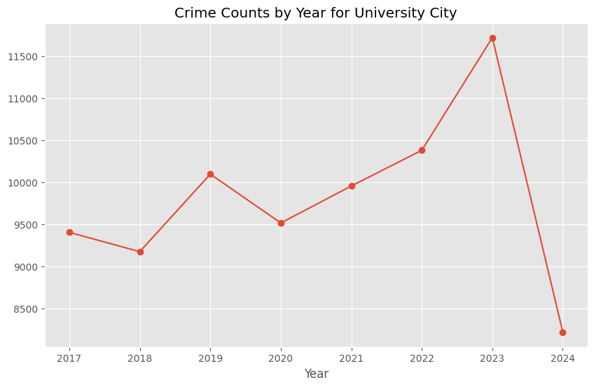

```python
plt.figure(figsize=(10, 6))
plt.plot(University_crime_counts['YEAR'], University_crime_counts['Count'], marker='o')
plt.title('Crime Counts by Year for University City')
plt.xlabel('Year')
```

# References:

1. https://www.charlottenc.gov/cmpd/News-Information/Crime-Statistics-Report
2. https://data.charlottenc.gov/datasets/charlotte::cmpd-incidents-1/about